# note1

### 통계계산 1주차

### 샘플링이란?

- 특정한 확률분포에 대응하는 샘플포인트를 추출하는 것.
- 예를들면 정규분포에서 10개의 샘프를 뽑는 것.

```r
## 예를들면 이런것 !!
rnorm(10)
```

1. 0.219517953706025

2. 0.408167135536757

3. -0.817061394244906

4. 1.3500236018462

5. 0.515215716716716

6. -1.61852945496081

7. 0.512410440656227

8. 0.874794225896805

9. -0.167238725314332

10. -0.192466257964213

### 의문: 샘플을 추출해서 어디에 활용하는가?

- 통계학/머신러닝에서 샘플링이 어떻게 활용되는가?
1. 훌륭한 계산기
   - 원의 면적구하기 $\rightarrow$ 원주율추정
   - 몬테카를로 적분: 각종 적분계산에 이용할 수 있다.
2. 리샘플링: 부스트랩, 잭나이프 $\rightarrow$ 통계편차, 추정치의 분산등을 계산할 수 있다.
   - 회귀분석에서 $V(\hat{\beta})$ 등을 구할 수 있음.
   - 통계학의 혁명 중 하나.
3. 모형의 파라메터 추정: 확률적 경사하강법
   - 예를들면 $\bf{y}=\bf{X}\boldsymbol{\beta}+\boldsymbol{\epsilon}$ 와 같은 모형에서 적절한 $\hat{\beta}$을 구하는데 이용할 수 있음.
   - 딥러닝과 같은 복잡한 모형에서의 파라메터도 효과적으로 추정가능
4. 사후분포(posterior)를 구하는데 사용
   - 베아지안 방법론의 비약적인 발전을 이끔: 계층모형, 은닉변수를 포함하는 모형에서 꽃을 피움.
   - 딥볼츠만머신, 잠재디리클레할당(LDA) $\rightarrow$ 토픽모델

### 샘플링을 사용하는 방법 = 수치해석적 방법 ?

- 아니다.
- 둘다 모두 컴퓨터를 활용하여 원하는 목적을 (근사적으로) 달성하는 느낌이 있음. 그래서 비슷하게 느껴짐.

아래의 용어들을 구분하면 좋다.

- 해석적, 해석해, closed form, $\dots$
- 수치적, 수치해석적, numerical, $\dots$
- 샘플링, 시뮬레이션, 확률, 랜덤, 분포, 몬테카를로, $\dots$

### 예제 (회귀모형의 계수를 해석적으로 추정 vs 수치해석적으로 추정)

아래와 같은 모형을 관찰했다고 하자.

```r
set.seed(1)
x<- 1:100/50
y<- 2*x-3*x^2+rnorm(100)*0.5
```

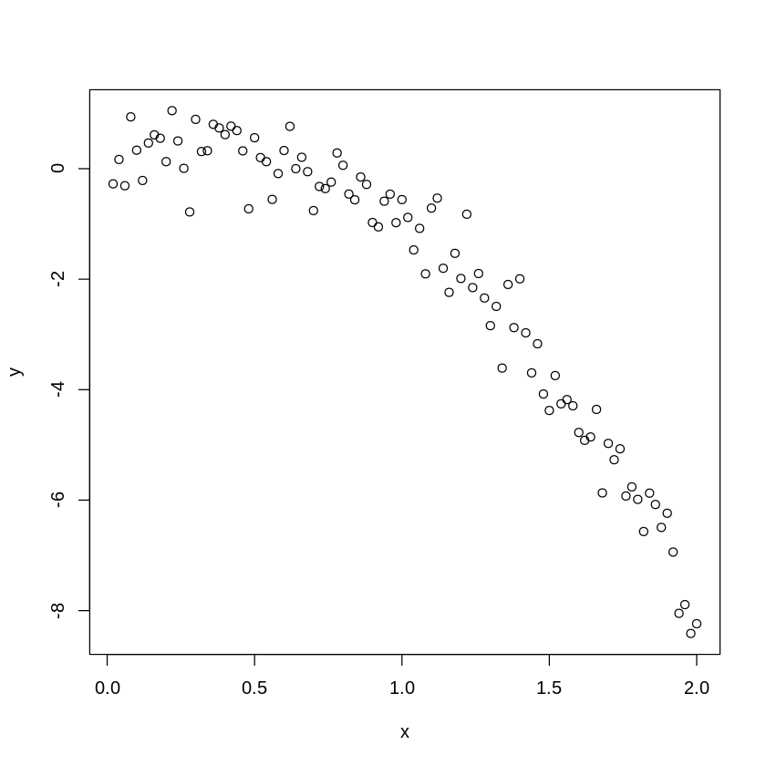

```r
plot(x,y)
```

트루모델은 아래와 같다.

$$y_i=2x_i-3x_i^2+\epsilon_i, \quad i=1,2,\dots,100$$

아래와 같은 모형을 설정하고 적합하자. (=적절한 파라메터($\beta_1,\beta_2$)를 구하자.)

$$y_i=\beta_1x_i+ \beta_2x_i^2+\epsilon_i$$

파라메터는 LSE로 구한다고 가정하자. 즉

$$L=\sum_i^n\epsilon_i^2$$

을 최소화하는 $\beta_1,\beta_2$를 구하자.

(풀이1) 해석적풀이: $L$을 최소화하는 해는 아래와 같음이 알려져있다.

$\boldsymbol{\hat\beta}=\big(\bf{X}'\bf{X}\big)^{-1}\bf{X}'\bf{y}$ $\rightarrow$ $\boldsymbol{\beta}$의 closed form, 해석해

이 공식(?)을 이용하여 계산을 한다.

```r
X=cbind(x,x^2)
solve(t(X)%*%X)%*%t(X)%*%y
```

A matrix: 2 × 1 of type dbl

| x | 2.146839 |
| --- | --- |
|  | -3.072298 |

참값인 2와 -3을 적절하게 추정하였음.

(풀이2) 수치해석적 풀이

$$L=\sum_{i=1}^n\epsilon_i^2=\big(\bf{y}-\bf{X}\boldsymbol{\beta}\big)^T(\bf{y}-\bf{X}\boldsymbol{\beta}\big)$$

```r
beta=c(1,1) ## 아무값이나 일단 넣자.
L=t(y-X%*%beta)%*%(y-X%*%beta)
```

```r
L
```

A matrix: 1 × 1 of type dbl

| 3732.619 |
| --- |

즉 `L`은 적당한 값 `beta`를 대입함에 따라 정의됨.

우리가 하고싶은것?: `L`을 최소화하고 싶음. $\rightarrow$ `L`을 작게 만드는 `beta`를 적당히 찾아보자.

```r
beta=c(2,2)
L1=t(y-X%*%beta)%*%(y-X%*%beta)
beta=c(-3,-3)
L2=t(y-X%*%beta)%*%(y-X%*%beta)
beta=c(2,-3)
L3=t(y-X%*%beta)%*%(y-X%*%beta)
```

`L1`, `L2`, `L3`, $\dots$ 를 계속 찾아가면서 가장 작은 `L_?`을 찾는다.

이 셋중에서는 `L3`가 가장 작은 값을 가질것!

확인:

```r
L1
```

A matrix: 1 × 1 of type dbl

| 8159.192 |
| --- |

```r
L2
```

A matrix: 1 × 1 of type dbl

| 3454.993 |
| --- |

```r
L3
```

A matrix: 1 × 1 of type dbl

| 20.26377 |
| --- |

... `beta`에 좀 더 다양한 값들을 충분히 넣어보고 적당한 해를 찾으면 된다.

(풀이3) 또 다른 수치해석적 풀이: 경사하강법

풀이2를 좀 더 체계적으로 정리하면?? `그리드서치`가 된다.

`그리드서치`보다 좀 더 효율적이고 체계적인 풀이가 있을까? $\rightarrow$ 경사하강법

먼저 `L`을 아래와 같은 함수의 형태로 정의하자.

```r
L<-function(beta){
    t(y-X%*%beta)%*%(y-X%*%beta)
}
```

`L`은 입력으로 길이가 2인 벡터를 받아서 손실값을 반환하는 함수이다.

```r
beta=c(2,2)
L(beta)
beta=c(-3,-3)
L(beta)
beta=c(2,-3)
L(beta)
```

A matrix: 1 × 1 of type dbl

| 8159.192 |
| --- |

A matrix: 1 × 1 of type dbl

| 3454.993 |
| --- |

A matrix: 1 × 1 of type dbl

| 20.26377 |
| --- |

시각화: $\big(\beta_1,\beta_2,L(\beta_1,\beta_2)\big)$를 그려보자.

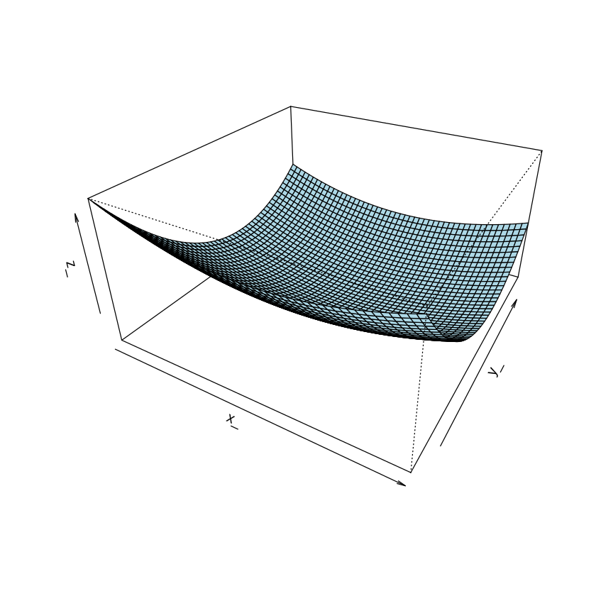

```r
x_ = beta1_ =seq(-20,20,length=50)
y_ = beta2_ =seq(-5,3,length=50)
L_ <- function(beta1,beta2){
    rtn<-c()
    for(k in 1:length(beta1)){
        rtn[k]<-sum((y-beta1[k]*x-beta2[k]*x^2)^2)
    }
    rtn
}
z_=outer(x_,y_,L_)
persp(x_,y_,z_,theta = 30, phi = 30, expand = 0.5, col = "lightblue")
#persp
```

$L$이 볼록함수이므로, 경사하강법으로 쉽게 최소점을 찾을 수 있다.